# CSC478_Assignment1

## Assignment 1

Experiment with Python, Numpy, and Pandas in order to perform some basic data preprocessing and analysis tasks

```python
import numpy as np
import pandas as pd
import matplotlib.pyplot as plt
%matplotlib inline
```

### 1. Explore the general characteristics of the data

```python
bk_table = pd.read_csv("bank_data.csv", index_col=0)

bk_table.shape
```

```
(600, 11)
```

```python
bk_table.head(10)
```

| id | age | income | children | gender | region | married | car | savings_acct | current_acct | mortgage | pep |
| --- | --- | --- | --- | --- | --- | --- | --- | --- | --- | --- | --- |
| ID12101 | 48 | 17546.00 | 1 | FEMALE | INNER_CITY | NO | NO | NO | NO | NO | YES |
| ID12102 | 40 | 30085.10 | 3 | MALE | TOWN | YES | YES | NO | YES | YES | NO |
| ID12103 | 51 | 16575.40 | 0 | FEMALE | INNER_CITY | YES | YES | YES | YES | NO | NO |
| ID12104 | 23 | 20375.40 | 3 | FEMALE | TOWN | YES | NO | NO | YES | NO | NO |
| ID12105 | 57 | 50576.30 | 0 | FEMALE | RURAL | YES | NO | YES | NO | NO | NO |
| ID12106 | 57 | 37869.60 | 2 | FEMALE | TOWN | YES | NO | YES | YES | NO | YES |
| ID12107 | 22 | 8877.07 | 0 | MALE | RURAL | NO | NO | NO | YES | NO | YES |
| ID12108 | 58 | 24946.60 | 0 | MALE | TOWN | YES | YES | YES | YES | NO | NO |
| ID12109 | 37 | 25304.30 | 2 | FEMALE | SUBURBAN | YES | YES | NO | NO | NO | NO |
| ID12110 | 54 | 24212.10 | 2 | MALE | TOWN | YES | YES | YES | YES | NO | NO |

```python
# shows numerical data

bk_table.describe()
```

|  | age | income | children |
| --- | --- | --- | --- |
| count | 600.000000 | 600.000000 | 600.000000 |
| mean | 42.395000 | 27524.031217 | 1.011667 |
| std | 14.424947 | 12899.468246 | 1.056752 |
| min | 18.000000 | 5014.210000 | 0.000000 |
| 25% | 30.000000 | 17264.500000 | 0.000000 |
| 50% | 42.000000 | 24925.300000 | 1.000000 |
| 75% | 55.250000 | 36172.675000 | 2.000000 |
| max | 67.000000 | 63130.100000 | 3.000000 |

```python
# Explore the general characteristics of the data as a whole

bk_table.describe(include="all")
```

|  | age | income | children | gender | region | married | car | savings_acct | current_acct | mortgage | pep |
| --- | --- | --- | --- | --- | --- | --- | --- | --- | --- | --- | --- |
| count | 600.000000 | 600.000000 | 600.000000 | 600 | 600 | 600 | 600 | 600 | 600 | 600 | 600 |
| unique | NaN | NaN | NaN | 2 | 4 | 2 | 2 | 2 | 2 | 2 | 2 |
| top | NaN | NaN | NaN | FEMALE | INNER_CITY | YES | NO | YES | YES | NO | NO |
| freq | NaN | NaN | NaN | 300 | 269 | 396 | 304 | 414 | 455 | 391 | 326 |
| mean | 42.395000 | 27524.031217 | 1.011667 | NaN | NaN | NaN | NaN | NaN | NaN | NaN | NaN |
| std | 14.424947 | 12899.468246 | 1.056752 | NaN | NaN | NaN | NaN | NaN | NaN | NaN | NaN |
| min | 18.000000 | 5014.210000 | 0.000000 | NaN | NaN | NaN | NaN | NaN | NaN | NaN | NaN |
| 25% | 30.000000 | 17264.500000 | 0.000000 | NaN | NaN | NaN | NaN | NaN | NaN | NaN | NaN |
| 50% | 42.000000 | 24925.300000 | 1.000000 | NaN | NaN | NaN | NaN | NaN | NaN | NaN | NaN |
| 75% | 55.250000 | 36172.675000 | 2.000000 | NaN | NaN | NaN | NaN | NaN | NaN | NaN | NaN |
| max | 67.000000 | 63130.100000 | 3.000000 | NaN | NaN | NaN | NaN | NaN | NaN | NaN | NaN |

```python
# check data type (catagorical/numeric)

bk_table.info()
```

```
<class 'pandas.core.frame.DataFrame'>
Index: 600 entries, ID12101 to ID12700
Data columns (total 11 columns):
 #   Column        Non-Null Count  Dtype
---  ------        --------------  -----
 0   age           600 non-null    int64
 1   income        600 non-null    float64
 2   children      600 non-null    int64
 3   gender        600 non-null    object
 4   region        600 non-null    object
 5   married       600 non-null    object
 6   car           600 non-null    object
 7   savings_acct  600 non-null    object
 8   current_acct  600 non-null    object
 9   mortgage      600 non-null    object
 10  pep           600 non-null    object
dtypes: float64(1), int64(2), object(8)
memory usage: 56.2+ KB
```

```python
bk_table.dtypes
```

```
age               int64
income          float64
children          int64
gender           object
region           object
married          object
car              object
savings_acct     object
current_acct     object
mortgage         object
pep              object
dtype: object
```

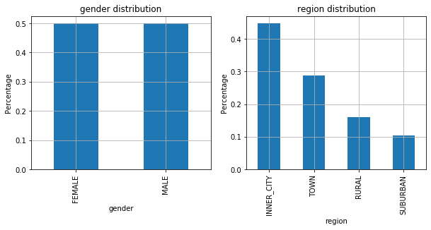

```python
# generate bar charts showing the distribution of categorical attributes

temp1 = bk_table["gender"].value_counts()/bk_table["gender"].count()
temp2 = bk_table["region"].value_counts()/bk_table["region"].count()
temp3 = bk_table["married"].value_counts()/bk_table["married"].count()
temp4 = bk_table["car"].value_counts()/bk_table["car"].count()
temp5 = bk_table["savings_acct"].value_counts()/bk_table["savings_acct"].count()
temp6 = bk_table["current_acct"].value_counts()/bk_table["current_acct"].count()
temp7 = bk_table["mortgage"].value_counts()/bk_table["mortgage"].count()
temp8 = bk_table["pep"].value_counts()/bk_table["pep"].count()

fig = plt.figure(figsize=(10,4))

ax1 = fig.add_subplot(121)
ax1.set_xlabel('gender')
ax1.set_ylabel('Percentage')
ax1.set_title("gender distribution")
temp1.plot(kind='bar', grid=True)

ax1 = fig.add_subplot(122)
ax1.set_xlabel('region')
ax1.set_ylabel('Percentage')
ax1.set_title("region distribution")
temp2.plot(kind='bar', grid=True)
```

[figure not shown]

```python
fig = plt.figure(figsize=(10,4))

ax1 = fig.add_subplot(121)
ax1.set_xlabel('married')
ax1.set_ylabel('Percentage')
ax1.set_title("married distribution")
temp3.plot(kind='bar', grid=True)

ax1 = fig.add_subplot(122)
ax1.set_xlabel('car')
ax1.set_ylabel('Percentage')
ax1.set_title("car distribution")
temp8.plot(kind='bar', grid=True)
```

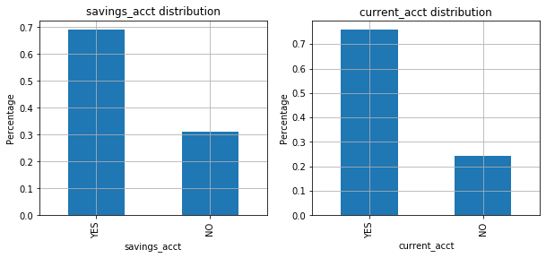

```python
fig = plt.figure(figsize=(10,4))

ax1 = fig.add_subplot(121)
ax1.set_xlabel('savings_acct')
ax1.set_ylabel('Percentage')
ax1.set_title("savings_acct distribution")
temp5.plot(kind='bar', grid=True)

ax1 = fig.add_subplot(122)
ax1.set_xlabel('current_acct')
ax1.set_ylabel('Percentage')
ax1.set_title("current_acct distribution")
temp6.plot(kind='bar', grid=True)
```

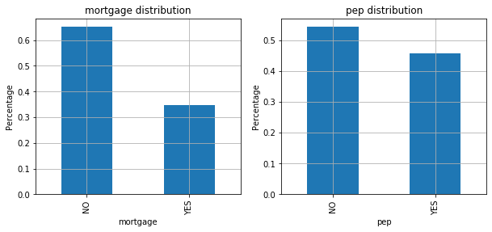

```python
fig = plt.figure(figsize=(10,4))

ax1 = fig.add_subplot(121)
ax1.set_xlabel('mortgage')
ax1.set_ylabel('Percentage')
ax1.set_title("mortgage distribution")
temp7.plot(kind='bar', grid=True)

ax1 = fig.add_subplot(122)
ax1.set_xlabel('pep')
ax1.set_ylabel('Percentage')
ax1.set_title("pep distribution")
temp8.plot(kind='bar', grid=True)
```

### 2. PEP

```python
# Compare and contrast the subsets of customers who buy/don't buy PEP

bk_table.columns
```

```
Index(['age', 'income', 'children', 'gender', 'region', 'married', 'car',
       'savings_acct', 'current_acct', 'mortgage', 'pep'],
      dtype='object')
```

```python
bk_table.groupby("pep")["age"].describe()
```

| pep | count | mean | std | min | 25% | 50% | 75% | max |
| --- | --- | --- | --- | --- | --- | --- | --- | --- |
| NO | 326.0 | 40.098160 | 14.123506 | 18.0 | 27.0 | 40.0 | 51.0 | 67.0 |
| YES | 274.0 | 45.127737 | 14.327991 | 18.0 | 34.0 | 45.0 | 58.0 | 67.0 |

```python
bk_table.groupby("pep")["income"].describe()
```

| pep | count | mean | std | min | 25% | 50% | 75% | max |
| --- | --- | --- | --- | --- | --- | --- | --- | --- |
| NO | 326.0 | 24900.953374 | 11661.123422 | 5014.21 | 15366.475 | 23105.00 | 31210.90 | 61554.6 |
| YES | 274.0 | 30644.919453 | 13609.613043 | 7756.36 | 19639.475 | 28080.05 | 38458.35 | 63130.1 |

```python
bk_table.groupby("pep")["children"].describe()
```

| pep | count | mean | std | min | 25% | 50% | 75% | max |
| --- | --- | --- | --- | --- | --- | --- | --- | --- |
| NO | 326.0 | 1.067485 | 1.195524 | 0.0 | 0.0 | 0.0 | 2.0 | 3.0 |
| YES | 274.0 | 0.945255 | 0.860571 | 0.0 | 0.0 | 1.0 | 1.0 | 3.0 |

```python
pd.crosstab(bk_table["pep"], bk_table["gender"])
```

| gender pep | FEMALE | MALE |
| --- | --- | --- |
| NO | 170 | 156 |
| YES | 130 | 144 |

- The data doesn't show a big relationship between buy/don't buy PEP and gender.

```python
pd.crosstab(bk_table["pep"], bk_table["region"])
```

| region pep | INNER_CITY | RURAL | SUBURBAN | TOWN |
| --- | --- | --- | --- | --- |
| NO | 146 | 50 | 28 | 102 |
| YES | 123 | 46 | 34 | 71 |

- Customers who live in INNER_CITY, RURAL, and TOWN are less likely to buy PEP.
- Customers who live in SUBURBAN are more likely to buy PEP.

```python
pd.crosstab(bk_table["pep"], bk_table["married"])
```

| married pep | NO | YES |
| --- | --- | --- |
| NO | 84 | 242 |
| YES | 120 | 154 |

- We can see that 242 customers who are married don't buy PEP, 154 customers who are married buy PEP.

```python
pd.crosstab(bk_table["pep"], bk_table["car"])
```

| car pep | NO | YES |
| --- | --- | --- |
| NO | 168 | 158 |
| YES | 136 | 138 |

- There is not much of a relationship between car ownership and buying PEP.

```python
pd.crosstab(bk_table["pep"], bk_table["savings_acct"])
```

| savings_acct pep | NO | YES |
| --- | --- | --- |
| NO | 91 | 235 |
| YES | 95 | 179 |

- 235 customers who have savings_acct don't buy PEP and 179 customers who have a saving_acct do buy PEP.
- 235 is bigger than 179, Therefore, customers who have savings_acct are less likely to buy PEP.

```python
pd.crosstab(bk_table["pep"], bk_table["current_acct"])
```

| current_acct pep | NO | YES |
| --- | --- | --- |
| NO | 82 | 244 |
| YES | 63 | 211 |

- There is no significant relationship between current_acct and PEP.

```python
pd.crosstab(bk_table["pep"], bk_table["mortgage"])
```

| mortgage pep | NO | YES |
| --- | --- | --- |
| NO | 209 | 117 |
| YES | 182 | 92 |

- 117 customers who have a mortgage didn't buy PEP. However, 209 customers who don't have a morgage don't buy PEP so that there is no significant relationship between a mortgage and PEP.

### 3. Use z-score normalization

```python
# Use z-score to std values of the income attribute
# Do not chagne the original age attribute or add discretized age to the table.

bk_income = bk_table["income"]
mean_income = bk_table["income"].mean()
std_income = bk_table["income"].std()

zscore_income = (bk_income - mean_income) / std_income
zscore_income.head(10)
```

```
id
ID12101   -0.773523
ID12102    0.198541
ID12103   -0.848766
ID12104   -0.554180
ID12105    1.787071
ID12106    0.802015
ID12107   -1.445560
ID12108   -0.199809
ID12109   -0.172079
ID12110   -0.256749
Name: income, dtype: float64
```

```python
# other way

z_score = lambda x: (x - x.mean()) / x.std() if (x.dtypes==np.float64 or x.dtypes==np.int64) else x
bk_std = bk_table.copy()
zscore_bk = bk_std.apply(z_score)
zscore_income = zscore_bk["income"]
zscore_income.head(10)
```

```
id
ID12101   -0.773523
ID12102    0.198541
ID12103   -0.848766
ID12104   -0.554180
ID12105    1.787071
ID12106    0.802015
ID12107   -1.445560
ID12108   -0.199809
ID12109   -0.172079
ID12110   -0.256749
Name: income, dtype: float64
```

### 4. Discretize the age attribute into 3 categories

```python
age_bins = pd.qcut(bk_table.age, [0, .33, .66, 1], labels=["young","mid-age","old"])
age_bins.head(10)
```

```
id
ID12101    mid-age
ID12102    mid-age
ID12103        old
ID12104      young
ID12105        old
ID12106        old
ID12107      young
ID12108        old
ID12109    mid-age
ID12110        old
Name: age, dtype: category
Categories (3, object): [young < mid-age < old]
```

```python
# check the original table

bk_table.head()
```

| id | age | income | children | gender | region | married | car | savings_acct | current_acct | mortgage | pep |
| --- | --- | --- | --- | --- | --- | --- | --- | --- | --- | --- | --- |
| ID12101 | 48 | 17546.0 | 1 | FEMALE | INNER_CITY | NO | NO | NO | NO | NO | YES |
| ID12102 | 40 | 30085.1 | 3 | MALE | TOWN | YES | YES | NO | YES | YES | NO |
| ID12103 | 51 | 16575.4 | 0 | FEMALE | INNER_CITY | YES | YES | YES | YES | NO | NO |
| ID12104 | 23 | 20375.4 | 3 | FEMALE | TOWN | YES | NO | NO | YES | NO | NO |
| ID12105 | 57 | 50576.3 | 0 | FEMALE | RURAL | YES | NO | YES | NO | NO | NO |

### 5. Min-Max Normalization to transform the values of all numeric attributes

```python
bk_numeric = bk_table[["income","age","children"]]
bk_numeric.head()
```

| id | income | age | children |
| --- | --- | --- | --- |
| ID12101 | 17546.0 | 48 | 1 |
| ID12102 | 30085.1 | 40 | 3 |
| ID12103 | 16575.4 | 51 | 0 |
| ID12104 | 20375.4 | 23 | 3 |
| ID12105 | 50576.3 | 57 | 0 |

```python
min_num = bk_table[["income","age","children"]].min()
max_num = bk_table[["income","age","children"]].max()
print(min_num, max_num)
```

```
income      5014.21
age           18.00
children       0.00
dtype: float64 income      63130.1
age            67.0
children        3.0
dtype: float64
```

```python
min_max_norm = (bk_table[["income","age","children"]] - min_num) / (max_num - min_num)
min_max_norm.head(10)
```

| id | income | age | children |
| --- | --- | --- | --- |
| ID12101 | 0.215634 | 0.612245 | 0.333333 |
| ID12102 | 0.431395 | 0.448980 | 1.000000 |
| ID12103 | 0.198933 | 0.673469 | 0.000000 |
| ID12104 | 0.264320 | 0.102041 | 1.000000 |
| ID12105 | 0.783987 | 0.795918 | 0.000000 |
| ID12106 | 0.565343 | 0.795918 | 0.666667 |
| ID12107 | 0.066468 | 0.081633 | 0.000000 |
| ID12108 | 0.342977 | 0.816327 | 0.000000 |
| ID12109 | 0.349132 | 0.387755 | 0.666667 |
| ID12110 | 0.330338 | 0.734694 | 0.666667 |

```python
# transform the values of (incom,age, children) in the original table

bk_table[["income","age","children"]] = min_max_norm[["income","age","children"]]
bk_table.head()
```

| id | age | income | children | gender | region | married | car | savings_acct | current_acct | mortgage | pep |
| --- | --- | --- | --- | --- | --- | --- | --- | --- | --- | --- | --- |
| ID12101 | 0.612245 | 0.215634 | 0.333333 | FEMALE | INNER_CITY | NO | NO | NO | NO | NO | YES |
| ID12102 | 0.448980 | 0.431395 | 1.000000 | MALE | TOWN | YES | YES | NO | YES | YES | NO |
| ID12103 | 0.673469 | 0.198933 | 0.000000 | FEMALE | INNER_CITY | YES | YES | YES | YES | NO | NO |
| ID12104 | 0.102041 | 0.264320 | 1.000000 | FEMALE | TOWN | YES | NO | NO | YES | NO | NO |
| ID12105 | 0.795918 | 0.783987 | 0.000000 | FEMALE | RURAL | YES | NO | YES | NO | NO | NO |

### 6. Convert the table into the standard spreadsheet format

```python
# each categorical attribute into multiple binary(dummy) attributes

bk_ssf = pd.get_dummies(bk_table)
bk_ssf.head(10)
```

| id | age | income | children | gender_FEMALE | gender_MALE | region_INNER_CITY | region_RURAL | region_SUBURBAN | region_TOWN | married_NO | ... | car_NO | car_YES | savings_acct_NO | savings_acct_YES | current_acct_NO | current_acct_YES | mortgage_NO | mortgage_YES | pep_NO | pep_YES |
| --- | --- | --- | --- | --- | --- | --- | --- | --- | --- | --- | --- | --- | --- | --- | --- | --- | --- | --- | --- | --- | --- |
| ID12101 | 0.612245 | 0.215634 | 0.333333 | 1 | 0 | 1 | 0 | 0 | 0 | 1 | ... | 1 | 0 | 1 | 0 | 1 | 0 | 1 | 0 | 0 | 1 |
| ID12102 | 0.448980 | 0.431395 | 1.000000 | 0 | 1 | 0 | 0 | 0 | 1 | 0 | ... | 0 | 1 | 1 | 0 | 0 | 1 | 0 | 1 | 1 | 0 |
| ID12103 | 0.673469 | 0.198933 | 0.000000 | 1 | 0 | 1 | 0 | 0 | 0 | 0 | ... | 0 | 1 | 0 | 1 | 0 | 1 | 1 | 0 | 1 | 0 |
| ID12104 | 0.102041 | 0.264320 | 1.000000 | 1 | 0 | 0 | 0 | 0 | 1 | 0 | ... | 1 | 0 | 1 | 0 | 0 | 1 | 1 | 0 | 1 | 0 |
| ID12105 | 0.795918 | 0.783987 | 0.000000 | 1 | 0 | 0 | 1 | 0 | 0 | 0 | ... | 1 | 0 | 0 | 1 | 1 | 0 | 1 | 0 | 1 | 0 |
| ID12106 | 0.795918 | 0.565343 | 0.666667 | 1 | 0 | 0 | 0 | 0 | 1 | 0 | ... | 1 | 0 | 0 | 1 | 0 | 1 | 1 | 0 | 0 | 1 |
| ID12107 | 0.081633 | 0.066468 | 0.000000 | 0 | 1 | 0 | 1 | 0 | 0 | 1 | ... | 1 | 0 | 1 | 0 | 0 | 1 | 1 | 0 | 0 | 1 |
| ID12108 | 0.816327 | 0.342977 | 0.000000 | 0 | 1 | 0 | 0 | 0 | 1 | 0 | ... | 0 | 1 | 0 | 1 | 0 | 1 | 1 | 0 | 1 | 0 |
| ID12109 | 0.387755 | 0.349132 | 0.666667 | 1 | 0 | 0 | 0 | 1 | 0 | 0 | ... | 0 | 1 | 1 | 0 | 1 | 0 | 1 | 0 | 1 | 0 |
| ID12110 | 0.734694 | 0.330338 | 0.666667 | 0 | 1 | 0 | 0 | 0 | 1 | 0 | ... | 0 | 1 | 0 | 1 | 0 | 1 | 1 | 0 | 1 | 0 |

10 rows × 21 columns

```python
# save this new table into a file called'bank_numeric.csv'

bk_ssf.to_csv("bank_numeric.csv", float_format="%1.2f")
```

### 7. Perform basic correlation analysis among the attributes

```python
# Min-Max normalization performed on the full numeric data set

bk_norm = (bk_ssf - bk_ssf.min()) / (bk_ssf.max() - bk_ssf.min())
bk_norm.head()
```

| id | age | income | children | gender_FEMALE | gender_MALE | region_INNER_CITY | region_RURAL | region_SUBURBAN | region_TOWN | married_NO | ... | car_NO | car_YES | savings_acct_NO | savings_acct_YES | current_acct_NO | current_acct_YES | mortgage_NO | mortgage_YES | pep_NO | pep_YES |
| --- | --- | --- | --- | --- | --- | --- | --- | --- | --- | --- | --- | --- | --- | --- | --- | --- | --- | --- | --- | --- | --- |
| ID12101 | 0.612245 | 0.215634 | 0.333333 | 1.0 | 0.0 | 1.0 | 0.0 | 0.0 | 0.0 | 1.0 | ... | 1.0 | 0.0 | 1.0 | 0.0 | 1.0 | 0.0 | 1.0 | 0.0 | 0.0 | 1.0 |
| ID12102 | 0.448980 | 0.431395 | 1.000000 | 0.0 | 1.0 | 0.0 | 0.0 | 0.0 | 1.0 | 0.0 | ... | 0.0 | 1.0 | 1.0 | 0.0 | 0.0 | 1.0 | 0.0 | 1.0 | 1.0 | 0.0 |
| ID12103 | 0.673469 | 0.198933 | 0.000000 | 1.0 | 0.0 | 1.0 | 0.0 | 0.0 | 0.0 | 0.0 | ... | 0.0 | 1.0 | 0.0 | 1.0 | 0.0 | 1.0 | 1.0 | 0.0 | 1.0 | 0.0 |
| ID12104 | 0.102041 | 0.264320 | 1.000000 | 1.0 | 0.0 | 0.0 | 0.0 | 0.0 | 1.0 | 0.0 | ... | 1.0 | 0.0 | 1.0 | 0.0 | 0.0 | 1.0 | 1.0 | 0.0 | 1.0 | 0.0 |
| ID12105 | 0.795918 | 0.783987 | 0.000000 | 1.0 | 0.0 | 0.0 | 1.0 | 0.0 | 0.0 | 0.0 | ... | 1.0 | 0.0 | 0.0 | 1.0 | 1.0 | 0.0 | 1.0 | 0.0 | 1.0 | 0.0 |

5 rows × 21 columns

```python
# Now, we can perform correlation analysis

corr_bkmatrix = bk_norm.corr()
corr_bkmatrix
```

|  | age | income | children | gender_FEMALE | gender_MALE | region_INNER_CITY | region_RURAL | region_SUBURBAN | region_TOWN | married_NO | ... | car_NO | car_YES | savings_acct_NO | savings_acct_YES | current_acct_NO | current_acct_YES | mortgage_NO | mortgage_YES | pep_NO | pep_YES |
| --- | --- | --- | --- | --- | --- | --- | --- | --- | --- | --- | --- | --- | --- | --- | --- | --- | --- | --- | --- | --- | --- |
| age | 1.000000 | 0.752726 | 0.023572 | 0.090081 | -0.090081 | -0.025171 | 0.018635 | 0.031345 | -0.008510 | -0.010394 | ... | -0.077733 | 0.077733 | -0.184389 | 0.184389 | 0.035312 | -0.035312 | 0.016154 | -0.016154 | -0.173825 | 0.173825 |
| income | 0.752726 | 1.000000 | 0.036761 | 0.023845 | -0.023845 | -0.047564 | 0.084776 | 0.029824 | -0.036431 | 0.008386 | ... | -0.081556 | 0.081556 | -0.266164 | 0.266164 | -0.031616 | 0.031616 | 0.014662 | -0.014662 | -0.221991 | 0.221991 |
| children | 0.023572 | 0.036761 | 1.000000 | 0.014206 | -0.014206 | -0.051222 | 0.089902 | -0.014122 | -0.007033 | 0.048716 | ... | -0.036455 | 0.036455 | -0.041536 | 0.041536 | -0.006238 | 0.006238 | 0.074339 | -0.074339 | 0.057663 | -0.057663 |
| gender_FEMALE | 0.090081 | 0.023845 | 0.014206 | 1.000000 | -1.000000 | -0.023459 | -0.009092 | -0.010951 | 0.040472 | 0.021110 | ... | 0.006667 | -0.006667 | 0.007207 | -0.007207 | -0.019466 | 0.019466 | 0.066465 | -0.066465 | 0.046843 | -0.046843 |
| gender_MALE | -0.090081 | -0.023845 | -0.014206 | -1.000000 | 1.000000 | 0.023459 | 0.009092 | 0.010951 | -0.040472 | -0.021110 | ... | -0.006667 | 0.006667 | -0.007207 | 0.007207 | 0.019466 | -0.019466 | -0.066465 | 0.066465 | -0.046843 | 0.046843 |
| region_INNER_CITY | -0.025171 | -0.047564 | -0.051222 | -0.023459 | 0.023459 | 1.000000 | -0.393444 | -0.306032 | -0.573814 | -0.003254 | ... | 0.018143 | -0.018143 | 0.091373 | -0.091373 | -0.007894 | 0.007894 | -0.002098 | 0.002098 | -0.001054 | 0.001054 |
| region_RURAL | 0.018635 | 0.084776 | 0.089902 | -0.009092 | 0.009092 | -0.393444 | 1.000000 | -0.148158 | -0.277798 | 0.022649 | ... | -0.024006 | 0.024006 | -0.036960 | 0.036960 | 0.008496 | -0.008496 | 0.051908 | -0.051908 | -0.019714 | 0.019714 |
| region_SUBURBAN | 0.031345 | 0.029824 | -0.014122 | -0.010951 | 0.010951 | -0.306032 | -0.148158 | 1.000000 | -0.216080 | -0.012483 | ... | 0.061184 | -0.061184 | -0.002605 | 0.002605 | -0.038157 | 0.038157 | -0.004635 | 0.004635 | -0.062508 | 0.062508 |
| region_TOWN | -0.008510 | -0.036431 | -0.007033 | 0.040472 | -0.040472 | -0.573814 | -0.277798 | -0.216080 | 1.000000 | -0.006369 | ... | -0.041604 | 0.041604 | -0.068654 | 0.068654 | 0.027431 | -0.027431 | -0.036591 | 0.036591 | 0.059115 | -0.059115 |
| married_NO | -0.010394 | 0.008386 | 0.048716 | 0.021110 | -0.021110 | -0.003254 | 0.022649 | -0.012483 | -0.006369 | 1.000000 | ... | -0.009571 | 0.009571 | 0.028604 | -0.028604 | -0.059996 | 0.059996 | -0.021711 | 0.021711 | -0.189578 | 0.189578 |
| married_YES | 0.010394 | -0.008386 | -0.048716 | -0.021110 | 0.021110 | 0.003254 | -0.022649 | 0.012483 | 0.006369 | -1.000000 | ... | 0.009571 | -0.009571 | -0.028604 | 0.028604 | 0.059996 | -0.059996 | 0.021711 | -0.021711 | 0.189578 | -0.189578 |
| car_NO | -0.077733 | -0.081556 | -0.036455 | 0.006667 | -0.006667 | 0.018143 | -0.024006 | 0.061184 | -0.041604 | -0.009571 | ... | 1.000000 | -1.000000 | 0.034310 | -0.034310 | -0.034783 | 0.034783 | -0.007743 | 0.007743 | 0.018917 | -0.018917 |
| car_YES | 0.077733 | 0.081556 | 0.036455 | -0.006667 | 0.006667 | -0.018143 | 0.024006 | -0.061184 | 0.041604 | 0.009571 | ... | -1.000000 | 1.000000 | -0.034310 | 0.034310 | 0.034783 | -0.034783 | 0.007743 | -0.007743 | -0.018917 | 0.018917 |
| savings_acct_NO | -0.184389 | -0.266164 | -0.041536 | 0.007207 | -0.007207 | 0.091373 | -0.036960 | -0.002605 | -0.068654 | 0.028604 | ... | 0.034310 | -0.034310 | 1.000000 | -1.000000 | 0.042511 | -0.042511 | -0.001588 | 0.001588 | -0.072779 | 0.072779 |
| savings_acct_YES | 0.184389 | 0.266164 | 0.041536 | -0.007207 | 0.007207 | -0.091373 | 0.036960 | 0.002605 | 0.068654 | -0.028604 | ... | -0.034310 | 0.034310 | -1.000000 | 1.000000 | -0.042511 | 0.042511 | 0.001588 | -0.001588 | 0.072779 | -0.072779 |
| current_acct_NO | 0.035312 | -0.031616 | -0.006238 | -0.019466 | 0.019466 | -0.007894 | 0.008496 | -0.038157 | 0.027431 | -0.059996 | ... | -0.034783 | 0.034783 | 0.042511 | -0.042511 | 1.000000 | -1.000000 | -0.036704 | 0.036704 | 0.025141 | -0.025141 |
| current_acct_YES | -0.035312 | 0.031616 | 0.006238 | 0.019466 | -0.019466 | 0.007894 | -0.008496 | 0.038157 | -0.027431 | 0.059996 | ... | 0.034783 | -0.034783 | -0.042511 | 0.042511 | -1.000000 | 1.000000 | 0.036704 | -0.036704 | -0.025141 | 0.025141 |
| mortgage_NO | 0.016154 | 0.014662 | 0.074339 | 0.066465 | -0.066465 | -0.002098 | 0.051908 | -0.004635 | -0.036591 | -0.021711 | ... | -0.007743 | 0.007743 | -0.001588 | 0.001588 | -0.036704 | 0.036704 | 1.000000 | -1.000000 | -0.024182 | 0.024182 |
| mortgage_YES | -0.016154 | -0.014662 | -0.074339 | -0.066465 | 0.066465 | 0.002098 | -0.051908 | 0.004635 | 0.036591 | 0.021711 | ... | 0.007743 | -0.007743 | 0.001588 | -0.001588 | 0.036704 | -0.036704 | -1.000000 | 1.000000 | 0.024182 | -0.024182 |
| pep_NO | -0.173825 | -0.221991 | 0.057663 | 0.046843 | -0.046843 | -0.001054 | -0.019714 | -0.062508 | 0.059115 | -0.189578 | ... | 0.018917 | -0.018917 | -0.072779 | 0.072779 | 0.025141 | -0.025141 | -0.024182 | 0.024182 | 1.000000 | -1.000000 |
| pep_YES | 0.173825 | 0.221991 | -0.057663 | -0.046843 | 0.046843 | 0.001054 | 0.019714 | 0.062508 | -0.059115 | 0.189578 | ... | -0.018917 | 0.018917 | 0.072779 | -0.072779 | -0.025141 | 0.025141 | 0.024182 | -0.024182 | -1.000000 | 1.000000 |

21 rows × 21 columns

```python
# To check the detailed data, I created a file.
# corr_bkmatrix.to_csv("bank_corr.csv", float_format="%1.2f")
```

**Discuss your results:**

- There is strong positive relationship(0.75) between `age` and `income`.
- There is low positive relationship(0.18) between `savings_acct_YES` and `age`.
- There is low negative relationship(-0.18) between `savings_acct_NO` and `age`.
- There is low positive relationship(0.17) between `pep_YES` and `age`.
- There is low negative relationship(-0.17) between `pep_NO` and `age`.
- There is low positive relationship(0.22) between `pep_YES` and `income`.
- There is low negative relationship(-0.22) between `pep_NO` and `income`.
- There is low positive relationship(0.19) between `pep_YES` and `married_No`.
- There is low negative relationship(-0.19) between `pep_NO` and `married_No`.
- There is low positive relationship(0.19) between `pep_NO` and `married_YES`.
- There is low negative relationship(-0.19) between `pep_YES` and `married_YES`.

### 8. Create a scatter plot of the (non-normalized) Income attribute relateve to Age

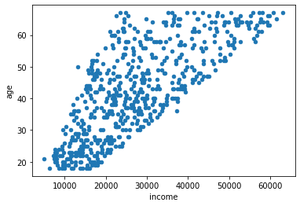

```python
# to get the non-normalized attribute, read the original file again

bk_table = pd.read_csv("bank_data.csv", index_col=0)

bk_table.plot(x="income", y="age", kind="scatter")
```

As you can see, it has strong positive correlation.

### 9. Create histograms for (non-normalized) Income and Age.

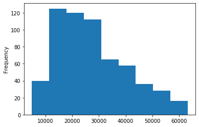

```python
# histogram for income

bk_table["income"].plot(kind="hist", bins=9)
```

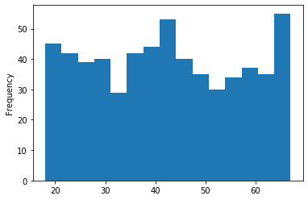

```python
# histogram for age

bk_table["age"].plot(kind="hist", bins=15)
```

### 10. Perform a cross-tabulation of the region with pep

```python
# using groupby

bk_table.groupby(["region","pep"])["pep"].count()
```

```
region      pep
INNER_CITY  NO     146
            YES    123
RURAL       NO      50
            YES     46
SUBURBAN    NO      28
            YES     34
TOWN        NO     102
            YES     71
Name: pep, dtype: int64
```

```python
# using cross-tab

region_ct = pd.crosstab(bk_table["region"], bk_table["pep"])
region_ct
```

| pep region | NO | YES |
| --- | --- | --- |
| INNER_CITY | 146 | 123 |
| RURAL | 50 | 46 |
| SUBURBAN | 28 | 34 |
| TOWN | 102 | 71 |

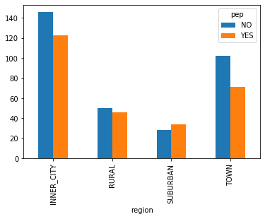

```python
# create a bar chart to visualize of the relationships

plt.show(region_ct.plot(kind="bar"))
```

### 11. Handle a modified version of the data

```python
m_bktable = pd.read_csv("bank_data_missing_vals.csv", index_col=0, na_values=["?"])
m_bktable.shape
```

```
(600, 11)
```

```python
m_bktable.head(10)
```

| id | age | income | children | gender | region | married | car | savings_acct | current_acct | mortgage | pep |
| --- | --- | --- | --- | --- | --- | --- | --- | --- | --- | --- | --- |
| ID12101 | 48.0 | 17546.00 | 1 | FEMALE | INNER_CITY | NO | NO | NO | NO | NO | YES |
| ID12102 | 40.0 | 30085.10 | 3 | MALE | TOWN | YES | YES | NO | YES | YES | NO |
| ID12103 | 51.0 | 16575.40 | 0 | FEMALE | INNER_CITY | YES | YES | YES | YES | NO | NO |
| ID12104 | 23.0 | NaN | 3 | FEMALE | TOWN | YES | NO | NO | YES | NO | NO |
| ID12105 | 57.0 | 50576.30 | 0 | FEMALE | RURAL | YES | NO | YES | NO | NO | NO |
| ID12106 | 57.0 | 37869.60 | 2 | FEMALE | TOWN | YES | NO | YES | YES | NO | YES |
| ID12107 | 22.0 | 8877.07 | 0 | MALE | NaN | NO | NO | NO | YES | NO | YES |
| ID12108 | 58.0 | 24946.60 | 0 | MALE | TOWN | YES | YES | YES | YES | NO | NO |
| ID12109 | 37.0 | NaN | 2 | FEMALE | SUBURBAN | YES | YES | NO | NO | NO | NO |
| ID12110 | 54.0 | 24212.10 | 2 | MALE | TOWN | YES | YES | YES | YES | NO | NO |

```python
# (a) determine all the attributes with missing values

m_bktable.info()
```

```
<class 'pandas.core.frame.DataFrame'>
Index: 600 entries, ID12101 to ID12700
Data columns (total 11 columns):
 #   Column        Non-Null Count  Dtype
---  ------        --------------  -----
 0   age           590 non-null    float64
 1   income        587 non-null    float64
 2   children      600 non-null    int64
 3   gender        590 non-null    object
 4   region        591 non-null    object
 5   married       600 non-null    object
 6   car           600 non-null    object
 7   savings_acct  600 non-null    object
 8   current_acct  600 non-null    object
 9   mortgage      600 non-null    object
 10  pep           600 non-null    object
dtypes: float64(2), int64(1), object(8)
memory usage: 56.2+ KB
```

We can see that the attributes of "age", "income", "gender", "region" contain missing values.

```python
m_bktable.describe(include="all")
```

|  | age | income | children | gender | region | married | car | savings_acct | current_acct | mortgage | pep |
| --- | --- | --- | --- | --- | --- | --- | --- | --- | --- | --- | --- |
| count | 590.000000 | 587.000000 | 600.000000 | 590 | 591 | 600 | 600 | 600 | 600 | 600 | 600 |
| unique | NaN | NaN | NaN | 2 | 4 | 2 | 2 | 2 | 2 | 2 | 2 |
| top | NaN | NaN | NaN | MALE | INNER_CITY | YES | NO | YES | YES | NO | NO |
| freq | NaN | NaN | NaN | 296 | 266 | 396 | 304 | 414 | 455 | 391 | 326 |
| mean | 42.376271 | 27475.594685 | 1.011667 | NaN | NaN | NaN | NaN | NaN | NaN | NaN | NaN |
| std | 14.450223 | 12917.081250 | 1.056752 | NaN | NaN | NaN | NaN | NaN | NaN | NaN | NaN |
| min | 18.000000 | 5014.210000 | 0.000000 | NaN | NaN | NaN | NaN | NaN | NaN | NaN | NaN |
| 25% | 30.000000 | 17244.150000 | 0.000000 | NaN | NaN | NaN | NaN | NaN | NaN | NaN | NaN |
| 50% | 42.000000 | 24867.600000 | 1.000000 | NaN | NaN | NaN | NaN | NaN | NaN | NaN | NaN |
| 75% | 55.750000 | 36131.050000 | 2.000000 | NaN | NaN | NaN | NaN | NaN | NaN | NaN | NaN |
| max | 67.000000 | 63130.100000 | 3.000000 | NaN | NaN | NaN | NaN | NaN | NaN | NaN | NaN |

There are many `"NaN"` values in this data.

```python
# (b) Show all the instances that contain a missing value

m_bktable[m_bktable.isnull().any(axis=1)]
```

| id | age | income | children | gender | region | married | car | savings_acct | current_acct | mortgage | pep |
| --- | --- | --- | --- | --- | --- | --- | --- | --- | --- | --- | --- |
| ID12104 | 23.0 | NaN | 3 | FEMALE | TOWN | YES | NO | NO | YES | NO | NO |
| ID12107 | 22.0 | 8877.07 | 0 | MALE | NaN | NO | NO | NO | YES | NO | YES |
| ID12109 | 37.0 | NaN | 2 | FEMALE | SUBURBAN | YES | YES | NO | NO | NO | NO |
| ID12135 | 43.0 | NaN | 0 | MALE | SUBURBAN | NO | NO | YES | YES | NO | YES |
| ID12142 | 47.0 | 26952.60 | 0 | NaN | INNER_CITY | YES | YES | NO | YES | NO | NO |
| ID12162 | 65.0 | 36589.00 | 1 | FEMALE | NaN | NO | YES | NO | YES | NO | YES |
| ID12178 | 61.0 | 49456.70 | 1 | NaN | INNER_CITY | YES | YES | YES | YES | YES | YES |
| ID12182 | 30.0 | NaN | 3 | MALE | INNER_CITY | NO | NO | NO | YES | NO | NO |
| ID12189 | 30.0 | 15848.70 | 0 | MALE | NaN | YES | YES | YES | NO | YES | NO |
| ID12202 | NaN | 11604.40 | 2 | FEMALE | INNER_CITY | YES | YES | YES | YES | NO | NO |
| ID12242 | 47.0 | 22791.40 | 0 | NaN | INNER_CITY | YES | NO | NO | YES | NO | NO |
| ID12248 | 20.0 | 18860.30 | 2 | FEMALE | NaN | NO | NO | YES | YES | NO | NO |
| ID12283 | 65.0 | NaN | 0 | FEMALE | INNER_CITY | NO | YES | YES | YES | YES | NO |
| ID12285 | 38.0 | NaN | 0 | FEMALE | INNER_CITY | NO | YES | YES | NO | YES | NO |
| ID12293 | 64.0 | 49024.90 | 3 | NaN | RURAL | YES | NO | YES | YES | NO | YES |
| ID12351 | 65.0 | NaN | 0 | MALE | INNER_CITY | NO | NO | YES | YES | YES | NO |
| ID12380 | 40.0 | 36972.40 | 1 | MALE | NaN | YES | NO | NO | YES | YES | YES |
| ID12381 | 32.0 | 22327.80 | 1 | NaN | INNER_CITY | YES | NO | NO | NO | NO | YES |
| ID12411 | NaN | 30658.70 | 0 | MALE | TOWN | YES | NO | YES | YES | NO | NO |
| ID12454 | 48.0 | NaN | 1 | MALE | TOWN | NO | YES | YES | YES | NO | YES |
| ID12461 | NaN | 51620.80 | 2 | FEMALE | TOWN | NO | YES | YES | YES | NO | YES |
| ID12462 | 56.0 | 19918.90 | 3 | MALE | NaN | YES | NO | YES | YES | YES | NO |
| ID12484 | 40.0 | 34836.80 | 1 | NaN | TOWN | YES | YES | YES | YES | NO | YES |
| ID12487 | 49.0 | NaN | 0 | MALE | INNER_CITY | NO | NO | NO | YES | NO | NO |
| ID12527 | NaN | NaN | 3 | FEMALE | TOWN | YES | NO | YES | NO | NO | NO |
| ID12544 | NaN | 33302.80 | 0 | MALE | TOWN | NO | YES | NO | YES | YES | YES |
| ID12557 | 32.0 | 13267.60 | 0 | FEMALE | NaN | YES | YES | YES | YES | YES | NO |
| ID12562 | 64.0 | 24554.10 | 0 | NaN | SUBURBAN | YES | YES | YES | NO | YES | NO |
| ID12566 | 57.0 | NaN | 2 | FEMALE | TOWN | YES | YES | YES | YES | YES | NO |
| ID12568 | 34.0 | 12810.20 | 3 | FEMALE | NaN | NO | NO | YES | YES | NO | YES |
| ID12579 | NaN | 23337.20 | 2 | MALE | TOWN | YES | NO | YES | YES | YES | NO |
| ID12610 | NaN | 11215.30 | 2 | FEMALE | RURAL | YES | YES | YES | YES | NO | YES |
| ID12639 | NaN | 38784.00 | 0 | FEMALE | INNER_CITY | YES | NO | YES | YES | NO | NO |
| ID12649 | NaN | 20736.20 | 1 | MALE | RURAL | YES | YES | YES | YES | NO | YES |
| ID12650 | 58.0 | 52662.50 | 1 | NaN | TOWN | YES | YES | YES | YES | YES | YES |
| ID12670 | 49.0 | 17944.20 | 1 | MALE | NaN | NO | YES | YES | YES | YES | YES |
| ID12685 | 33.0 | NaN | 1 | NaN | TOWN | YES | NO | YES | YES | YES | YES |
| ID12692 | NaN | 31473.90 | 2 | FEMALE | INNER_CITY | NO | NO | YES | YES | YES | YES |
| ID12693 | 48.0 | 20268.00 | 0 | NaN | TOWN | YES | NO | YES | YES | NO | NO |
| ID12697 | 30.0 | NaN | 0 | FEMALE | INNER_CITY | YES | YES | YES | YES | NO | NO |

```python
# (c) Fill the missing values using the mean value for the attribute

# numeric attribute contains missing value:"age", "income"

# age
age_mean = m_bktable.age.mean()
m_bktable.age.fillna(age_mean, axis=0, inplace=True)
m_bktable.head(10)
```

| id | age | income | children | gender | region | married | car | savings_acct | current_acct | mortgage | pep |
| --- | --- | --- | --- | --- | --- | --- | --- | --- | --- | --- | --- |
| ID12101 | 48.0 | 17546.00 | 1 | FEMALE | INNER_CITY | NO | NO | NO | NO | NO | YES |
| ID12102 | 40.0 | 30085.10 | 3 | MALE | TOWN | YES | YES | NO | YES | YES | NO |
| ID12103 | 51.0 | 16575.40 | 0 | FEMALE | INNER_CITY | YES | YES | YES | YES | NO | NO |
| ID12104 | 23.0 | NaN | 3 | FEMALE | TOWN | YES | NO | NO | YES | NO | NO |
| ID12105 | 57.0 | 50576.30 | 0 | FEMALE | RURAL | YES | NO | YES | NO | NO | NO |
| ID12106 | 57.0 | 37869.60 | 2 | FEMALE | TOWN | YES | NO | YES | YES | NO | YES |
| ID12107 | 22.0 | 8877.07 | 0 | MALE | NaN | NO | NO | NO | YES | NO | YES |
| ID12108 | 58.0 | 24946.60 | 0 | MALE | TOWN | YES | YES | YES | YES | NO | NO |
| ID12109 | 37.0 | NaN | 2 | FEMALE | SUBURBAN | YES | YES | NO | NO | NO | NO |
| ID12110 | 54.0 | 24212.10 | 2 | MALE | TOWN | YES | YES | YES | YES | NO | NO |

```python
# income
income_mean = m_bktable.income.mean()
m_bktable.income.fillna(income_mean, axis=0, inplace=True)
m_bktable.head(10)
```

| id | age | income | children | gender | region | married | car | savings_acct | current_acct | mortgage | pep |
| --- | --- | --- | --- | --- | --- | --- | --- | --- | --- | --- | --- |
| ID12101 | 48.0 | 17546.000000 | 1 | FEMALE | INNER_CITY | NO | NO | NO | NO | NO | YES |
| ID12102 | 40.0 | 30085.100000 | 3 | MALE | TOWN | YES | YES | NO | YES | YES | NO |
| ID12103 | 51.0 | 16575.400000 | 0 | FEMALE | INNER_CITY | YES | YES | YES | YES | NO | NO |
| ID12104 | 23.0 | 27475.594685 | 3 | FEMALE | TOWN | YES | NO | NO | YES | NO | NO |
| ID12105 | 57.0 | 50576.300000 | 0 | FEMALE | RURAL | YES | NO | YES | NO | NO | NO |
| ID12106 | 57.0 | 37869.600000 | 2 | FEMALE | TOWN | YES | NO | YES | YES | NO | YES |
| ID12107 | 22.0 | 8877.070000 | 0 | MALE | NaN | NO | NO | NO | YES | NO | YES |
| ID12108 | 58.0 | 24946.600000 | 0 | MALE | TOWN | YES | YES | YES | YES | NO | NO |
| ID12109 | 37.0 | 27475.594685 | 2 | FEMALE | SUBURBAN | YES | YES | NO | NO | NO | NO |
| ID12110 | 54.0 | 24212.100000 | 2 | MALE | TOWN | YES | YES | YES | YES | NO | NO |

```python
# (d) drop all rows where a categorical attribute contains a missing value

# categorical attribute contains missing value:"gender", "region"
m_bktable.dropna(axis=0, inplace=True)
```

```python
m_bktable.shape
```

```
(581, 11)
```

There are 19 deleted rows from the original data(600,11).

```python
# (e) show that the final resulting table does not contain missing values
m_bktable.tail(10)
```

| id | age | income | children | gender | region | married | car | savings_acct | current_acct | mortgage | pep |
| --- | --- | --- | --- | --- | --- | --- | --- | --- | --- | --- | --- |
| ID12690 | 29.000000 | 12623.400000 | 1 | MALE | SUBURBAN | YES | YES | YES | YES | NO | NO |
| ID12691 | 25.000000 | 23818.600000 | 0 | MALE | INNER_CITY | YES | NO | NO | NO | NO | NO |
| ID12692 | 42.376271 | 31473.900000 | 2 | FEMALE | INNER_CITY | NO | NO | YES | YES | YES | YES |
| ID12694 | 65.000000 | 51417.000000 | 2 | MALE | SUBURBAN | YES | NO | YES | YES | NO | YES |
| ID12695 | 59.000000 | 30971.800000 | 3 | FEMALE | RURAL | YES | YES | YES | YES | YES | NO |
| ID12696 | 61.000000 | 47025.000000 | 2 | FEMALE | INNER_CITY | NO | YES | YES | YES | YES | NO |
| ID12697 | 30.000000 | 27475.594685 | 0 | FEMALE | INNER_CITY | YES | YES | YES | YES | NO | NO |
| ID12698 | 31.000000 | 15976.300000 | 0 | FEMALE | TOWN | YES | YES | YES | NO | NO | YES |
| ID12699 | 29.000000 | 14711.800000 | 0 | MALE | INNER_CITY | YES | NO | YES | NO | YES | NO |
| ID12700 | 38.000000 | 26671.600000 | 0 | MALE | TOWN | NO | YES | NO | YES | YES | YES |

You can also check that `ID12693` has been dropped and does not existed in this data.